# Dataset 1 RNA Sequencing of oral carcinomas vs matched normal tissue

## This example is a remake of the example presented in the edgeR documentation

```r
# Clear variables
rm(list=ls())
#Get path
path<-getwd(); path
```

```
[1] "C:/Users/Acer/OneDrive - Universidade de Aveiro/GitHub Projects/edgeR_gene_counts/RStudio_Dataset 1_Example"
```

```r
# Set path
setwd(path)
```

## Important libraries

```r
library(GO.db)
```

```r
load("Transcript_raw_counts.RData")
```

```r
head(Transcript_raw_counts)
```

| idRefSeq | nameOfGene | numberOfExons | 8N | 8T | 33N | 33T | 51N | 51T |
| --- | --- | --- | --- | --- | --- | --- | --- | --- |
| NM_182502 | TMPRSS11B | 10 | 2592 | 3 | 7805 | 321 | 3372 | 9 |
| NM_003280 | TNNC1 | 6 | 1684 | 0 | 1787 | 7 | 4894 | 559 |
| NM_152381 | XIRP2 | 10 | 9915 | 15 | 10396 | 48 | 23309 | 7181 |
| NM_022438 | MAL | 3 | 2496 | 2 | 3585 | 239 | 1596 | 7 |
| NM_001100112 | MYH2 | 40 | 4389 | 7 | 7944 | 16 | 9262 | 1818 |
| NM_017534 | MYH2 | 40 | 4402 | 7 | 7943 | 16 | 9244 | 1815 |

# Lets rename the column names to be equal to the ones used in the edgeR document.

```r
Transcript_raw_counts <- as.data.frame(Transcript_raw_counts)

colnames(Transcript_raw_counts)<- c("RefSeqID", "Symbol", "NbrOfExons", "8N", "8T", "33N", "33T", "51N", "51T")

head(Transcript_raw_counts)
```

|  | RefSeqID | Symbol | NbrOfExons | 8N | 8T | 33N | 33T | 51N | 51T |
| --- | --- | --- | --- | --- | --- | --- | --- | --- | --- |
| 1 | NM_182502 | TMPRSS11B | 10 | 2592 | 3 | 7805 | 321 | 3372 | 9 |
| 2 | NM_003280 | TNNC1 | 6 | 1684 | 0 | 1787 | 7 | 4894 | 559 |
| 3 | NM_152381 | XIRP2 | 10 | 9915 | 15 | 10396 | 48 | 23309 | 7181 |
| 4 | NM_022438 | MAL | 3 | 2496 | 2 | 3585 | 239 | 1596 | 7 |
| 5 | NM_001100112 | MYH2 | 40 | 4389 | 7 | 7944 | 16 | 9262 | 1818 |
| 6 | NM_017534 | MYH2 | 40 | 4402 | 7 | 7943 | 16 | 9244 | 1815 |

```r
NA
```

#Lets rename our dataframe:

```r
rawdata <- Transcript_raw_counts
```

# Now we want to insert the data in a DGEList object:

```r
y <- DGEList(counts=rawdata[,4:9], genes=rawdata[,1:3])
```

# Genes annotation:

```r
 library(org.Hs.eg.db) #Bioconductor annotation data package - This package is updated biannually

 idfound <- y$genes$RefSeqID %in% mappedRkeys(org.Hs.egREFSEQ)
 y <- y[idfound,]
 dim(y)
```

```
[1] 15534     6
```

```r
egREFSEQ <- toTable(org.Hs.egREFSEQ)
head(egREFSEQ)
```

|  | gene_id | accession |
| --- | --- | --- |
| 1 | 1 | NM_130786 |
| 2 | 1 | NP_570602 |
| 3 | 2 | NM_000014 |
| 4 | 2 | NM_001347423 |
| 5 | 2 | NM_001347424 |
| 6 | 2 | NM_001347425 |

```r
m <- match(y$genes$RefSeqID, egREFSEQ$accession)
y$genes$EntrezGene <- egREFSEQ$gene_id[m]

egSYMBOL <- toTable(org.Hs.egSYMBOL)
head(egSYMBOL)
```

|  | gene_id | symbol |
| --- | --- | --- |
| 1 | 1 | A1BG |
| 2 | 2 | A2M |
| 3 | 3 | A2MP1 |
| 4 | 9 | NAT1 |
| 5 | 10 | NAT2 |
| 6 | 11 | NATP |

```r
m <- match(y$genes$EntrezGene, egSYMBOL$gene_id)
y$genes$Symbol <- egSYMBOL$symbol[m]
head(y$genes)
```

|  | RefSeqID | Symbol | NbrOfExons | EntrezGene |
| --- | --- | --- | --- | --- |
| 1 | NM_182502 | TMPRSS11B | 10 | 132724 |
| 2 | NM_003280 | TNNC1 | 6 | 7134 |
| 3 | NM_152381 | XIRP2 | 10 | 129446 |
| 4 | NM_022438 | MAL | 3 | 4118 |
| 5 | NM_001100112 | MYH2 | 40 | 4620 |
| 6 | NM_017534 | MYH2 | 40 | 4620 |

##Filtering and normalization

Different RefSeq transcripts for the same gene symbol count predominantly the same reads (visible, per example, in the Symbol MYH2 in the previous table).

So we keep one transcript for each gene symbol. We choose the transcript with highest overall count:

```r
o <- order(rowSums(y$counts), decreasing=TRUE)
y <- y[o,]
d <- duplicated(y$genes$Symbol)
y <- y[!d,]
nrow(y)
```

```
[1] 10510
```

Through this filtering we reduced the number of genes: 15534 to 10510.

Normally we would also filter lowly expressed genes. For this data, all transcripts already have at least 50 reads for all samples of at least one of the tissues types.

##Recompute the library sizes

```r
y$samples$lib.size <- colSums(y$counts)
```

```r
rownames(y$counts) <- rownames(y$genes) <- y$genes$EntrezGene
y$genes$EntrezGene <- NULL
```

## TMM normalization

```r
y <- normLibSizes(y)
y$samples
```

|  | group | lib.size | norm.factors |
| --- | --- | --- | --- |
| 8N | 1 | 7987830 | 1.1460813 |
| 8T | 1 | 7370197 | 1.0856403 |
| 33N | 1 | 15752765 | 0.6721946 |
| 33T | 1 | 14042177 | 0.9734641 |
| 51N | 1 | 21536577 | 1.0317452 |
| 51T | 1 | 15191722 | 1.1904503 |

## Data exploration

The first step of an analysis should be to examine the samples for outliers and for other relationships. The function plotMDS produces a plot in which distances between samples correspond to leading biological coefficient of variation (BCV) between those samples:

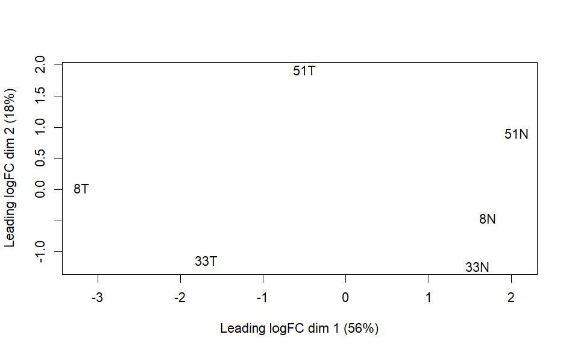

```r
plotMDS(y)
```

## PLOT INTERPRETATION

In the plot, dimension 1 separates the tumor from the normal samples, while dimension 2 roughly corresponds to patient number. This confirms the paired nature of the samples. The tumor samples appear more heterogeneous than the normal samples.

## Design Matrix

Before we fit negative binomial GLMs, we need to define our design matrix based on the experimental design.

Here we want to test for differential expression between tumour and normal tissues within patients, i.e. adjusting for differences between patients. In statistical terms, this is an additive linear model with patient as the blocking factor:

```r
Patient <- factor(c(8,8,33,33,51,51))
Tissue <- factor(c("N","T","N","T","N","T"))
data.frame(Sample=colnames(y),Patient,Tissue)
```

| Sample | Patient | Tissue |
| --- | --- | --- |
| 8N | 8 | N |
| 8T | 8 | T |
| 33N | 33 | N |
| 33T | 33 | T |
| 51N | 51 | N |
| 51T | 51 | T |

```r
design <- model.matrix(~Patient+Tissue)
rownames(design) <- colnames(y)
design
```

```
    (Intercept) Patient33 Patient51 TissueT
8N            1         0         0       0
8T            1         0         0       1
33N           1         1         0       0
33T           1         1         0       1
51N           1         0         1       0
51T           1         0         1       1
attr(,"assign")
[1] 0 1 1 2
attr(,"contrasts")
attr(,"contrasts")$Patient
[1] "contr.treatment"

attr(,"contrasts")$Tissue
[1] "contr.treatment"
```

# Dispersion estimation

```r
y <- estimateDisp(y, design, robust=TRUE)
y$common.dispersion
```

```
[1] 0.1592919
```

The square root of the common dispersion gives the coefficient of variation of biological variation. Here the common dispersion is found to be 0.159, so the coefficient of biological variation is around 0.4.

The dispersion estimates can be viewed in a BCV plot:

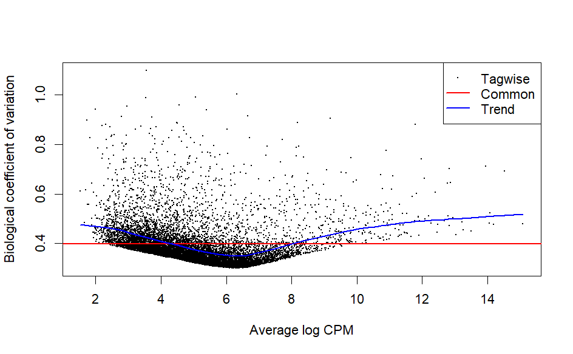

```r
plotBCV(y)
```

## Differential expression

Now proceed to determine differentially expressed genes. Fit genewise glms:

```r
fit <- glmFit(y, design)
```

Conduct likelihood ratio tests for tumour vs normal tissue differences and show the top genes:

```r
lrt <- glmLRT(fit)
topTags(lrt)
```

```
Coefficient:  TissueT
```

|  | RefSeqID | Symbol | NbrOfExons | logFC | logCPM | LR | PValue | FDR |
| --- | --- | --- | --- | --- | --- | --- | --- | --- |
| 5737 | NM_001039585 | PTGFR | 4 | -5.182225 | 4.741083 | 98.67443 | 2.976201e-23 | 3.127987e-19 |
| 5744 | NM_002820 | PTHLH | 4 | 3.969654 | 6.207457 | 92.12917 | 8.119974e-22 | 4.267046e-18 |
| 3479 | NM_001111283 | IGF1 | 5 | -3.988478 | 5.715269 | 86.51289 | 1.388294e-20 | 4.863656e-17 |
| 1288 | NM_033641 | COL4A6 | 45 | 3.655722 | 5.715653 | 77.51786 | 1.315280e-18 | 3.455898e-15 |
| 10351 | NM_007168 | ABCA8 | 38 | -3.983306 | 4.937163 | 75.90088 | 2.982678e-18 | 6.269590e-15 |
| 5837 | NM_005609 | PYGM | 20 | -5.480972 | 5.986934 | 75.35523 | 3.932050e-18 | 6.887642e-15 |
| 487 | NM_004320 | ATP2A1 | 23 | -4.620947 | 5.964180 | 74.80370 | 5.199206e-18 | 7.806237e-15 |
| 27179 | NM_014440 | IL36A | 4 | -6.166114 | 5.401982 | 72.19874 | 1.945799e-17 | 2.556293e-14 |
| 196374 | NM_173352 | KRT78 | 9 | -4.245607 | 7.610422 | 70.80364 | 3.946083e-17 | 4.608148e-14 |
| 83699 | NM_031469 | SH3BGRL2 | 4 | -3.934706 | 5.535119 | 67.77044 | 1.836823e-16 | 1.930501e-13 |

Note that glmLRT has conducted a test for the last coefficient in the linear model, which we can see is the tumor vs normal tissue effect:

```r
colnames(design)
```

```
[1] "(Intercept)" "Patient33"   "Patient51"   "TissueT"
```

The genewise tests are for tumor vs normal differential expression, adjusting for baseline differences between the three patients. The tests can be viewed as analogous to paired t-tests. The top DE tags have tiny p-values and FDR values, as well as large fold changes. Here’s a closer look at the counts-per-million in individual samples for the top genes:

```r
o <- order(lrt$table$PValue)
cpm(y)[o[1:10],]
```

```
               8N          8T        33N         33T        51N          51T
5737    49.701234   0.8748488  27.103794   0.8778633  78.126900   2.54354579
5744     7.318643  95.8584341  11.804788 204.1763670   6.885608 116.33957252
3479    50.247401   3.1244600  32.392339   1.9020371 211.653693  14.21067972
1288    12.124916 140.2257667   6.327367  94.4434575   4.860429  56.84271889
10351   52.650538   3.1244600  39.475212   2.1215029  79.206996   6.08239210
5837   152.817640   2.7495248 119.653335   1.1704844  97.703629   5.69533078
487    107.922679   3.1244600 147.134883   3.8040742 102.834082   8.90241025
27179   40.088688   1.2497840 172.255472   3.2919873  36.093188   0.05529447
196374 372.267704  20.7464147 581.551096  47.7703933 145.092815   4.53414684
83699   96.234697   5.1241145 117.197939   5.4134902  48.199257   5.41885842
```

We see that all the top genes have consistent tumour vs normal changes for the three patients. The total number of differentially expressed genes at 5% FDR is given by:

```r
summary(decideTests(lrt))
```

```
       TissueT
Down       938
NotSig    9241
Up         331
```

Plot log-fold change against log-counts per million, with DE genes highlighted: (The blue lines indicate 2-fold changes)

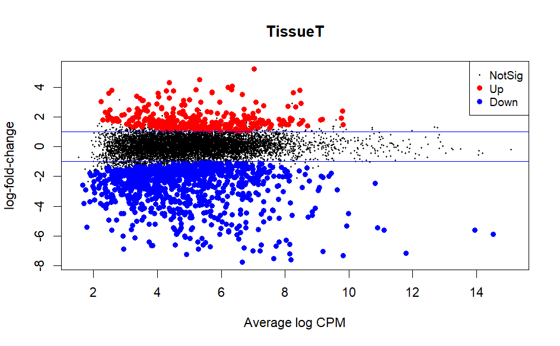

```r
plotMD(lrt)
abline(h=c(-1, 1), col="blue")
```

## Gene ontology analysis

We perform a gene ontology analysis focusing on the ontology of biological process (BP). The genes up-regulated in the tumors tend to be associated with cell differentiation, cell migration and tissue morphogenesis:

```r
go <- goana(lrt)
topGO(go, ont="BP", sort="Up", n=30, truncate=30)
```

|  | Term | Ont | N | Up | Down | P.Up | P.Down |
| --- | --- | --- | --- | --- | --- | --- | --- |
| GO:0009888 | tissue development | BP | 1228 | 82 | 185 | 1.305119e-11 | 5.153357e-14 |
| GO:0007155 | cell adhesion | BP | 917 | 65 | 158 | 2.557167e-10 | 3.445010e-17 |
| GO:0060429 | epithelium development | BP | 746 | 55 | 93 | 1.948365e-09 | 4.703495e-04 |
| GO:0022008 | neurogenesis | BP | 987 | 65 | 108 | 5.274562e-09 | 1.295666e-02 |
| GO:0009653 | anatomical structure morpho... | BP | 1634 | 92 | 232 | 5.548083e-09 | 1.126923e-14 |
| GO:0008544 | epidermis development | BP | 240 | 27 | 32 | 8.405354e-09 | 1.380789e-02 |
| GO:0048513 | animal organ development | BP | 1823 | 98 | 264 | 1.646958e-08 | 4.216505e-18 |
| GO:0048729 | tissue morphogenesis | BP | 403 | 35 | 51 | 4.541025e-08 | 6.551671e-03 |
| GO:0007399 | nervous system development | BP | 1457 | 81 | 152 | 1.124554e-07 | 1.815392e-02 |
| GO:0007275 | multicellular organism deve... | BP | 2730 | 128 | 318 | 1.827056e-07 | 9.482975e-09 |

[output cut: 20 more lines]